# Lab 6

David Wilson

4/13/2022

#### We again return to our RNA seq dataset of E. Coli genes from mice. The URL is here: http://afodor.github.io/classes/stats2015/longitdunalRNASeqData.zip As before, read and normalize the counts table ( “nc101_scaff_dataCounts.txt” into R).

###### (The first 3 columns are “day 2”, the next 3 columns are “week 12” and the last 5 are “week 18” (even though they say w20)).

```r
setwd('/Users/dwils152/Google Drive/My Drive/spring2022/adv_stats/BINF8310/Lab6')
data <- read.table("nc101_scaff_dataCounts.txt",sep="\t",header=TRUE,row.names=1)
data <- data[apply(data, 1, median)> 5,] #filter out rare genes
norm <- data

for ( i in 1:ncol(data) ) {
    col_sum = sum(data[,i])
    norm[,i] = norm[,i]/col_sum
}
```

##### A) For each row in the spreadsheet, perform a one-way ANOVA with categories “day 2”, “week 12” and “week 18”. Plot out the histogram of all p-values. How many genes are significant at a BH FDR-corrected 0.05 threshold.

```r
library(ggplot2)
library(dplyr)
library(tidyr)
library(reshape2)
library(tibble)
library(ggpubr)

#normalized data
norm_data <- as.data.frame(norm)

#rename, and create factors
names(norm_data) <- sub("_..", "", names(norm_data))
time_points <- c(rep("D2", 3), rep("W12", 3), rep("w20", 5))
time_points <- factor(time_points)

p_values_A <- vector(length=nrow(norm_data))

#get p-values for each gene
for (gene in 1:nrow(norm_data)) {
  gene_exp <- unlist(norm_data[gene,]) #make list into numeric vector for use in lm
  model <- lm(gene_exp ~ time_points)
  anova <- anova(model)
  p_values_A[gene] <- anova$"Pr(>F)"[1]
}

#calculate p-values
adj_p_values_A <- p.adjust(p_values_A, method='BH')
sig_p_values <- adj_p_values_A[adj_p_values_A <= 0.05]

paste("There are", length(sig_p_values), "significantly expressed genes at 5% FDR.")
```

```
## [1] "There are 612 significantly expressed genes at 5% FDR."
```

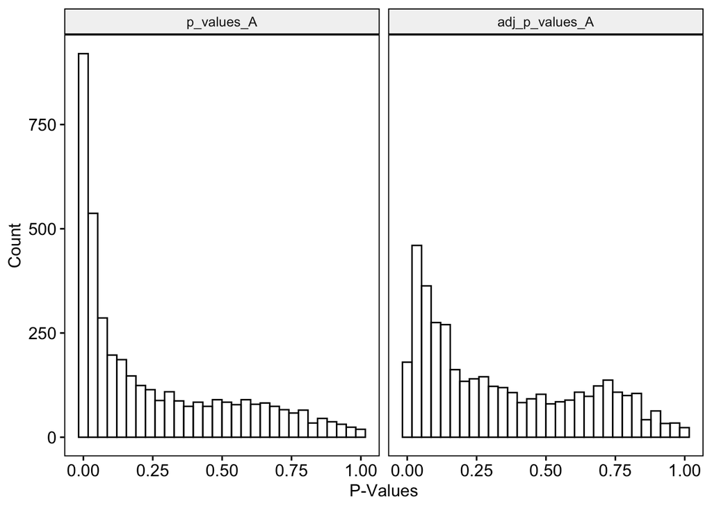

```r
#plot adjusted and unadjusted p-values
pvals_df <- data.frame(p_values_A, adj_p_values_A)
gghistogram(pvals_df,
       x = c("p_values_A", "adj_p_values_A"),
       y = "..count..",
       combine = TRUE,
       xlab = "P-Values",
       ylab = "Count",
       palette = "jco",
)
```

##### B) Next make an ANOVA as a linear regression as a function of time (so 2 days, 86 days and 128 days). Plot out the histogram of all p-values. How many genes are significant at a BH FDR-corrected 0.05 threshold.

```r
#vector of p-values for our new model
p_values_B <- vector(length=nrow(norm_data))
time_points <- as.numeric(c(rep(2, 3), rep(86, 3), rep(128, 5)))

#get p-values for each gene
for (gene in 1:nrow(norm_data)) {

  gene_exp <- as.numeric(unlist(data[gene,])) #make list into numeric vector for use in lm
  model <- lm(gene_exp ~ time_points)
  anova <- anova(model)
  p_values_B[gene] <- anova$"Pr(>F)"[1]
  #two_param_model[gene] <- model

}

#plot adjusted p-values
adj_p_values_B <- p.adjust(p_values_B, method='BH')
sig_p_values <- adj_p_values_B[adj_p_values_B <= 0.05]

paste("There are", length(sig_p_values), "significantly expressed genes at 5% FDR.")
```

```
## [1] "There are 0 significantly expressed genes at 5% FDR."
```

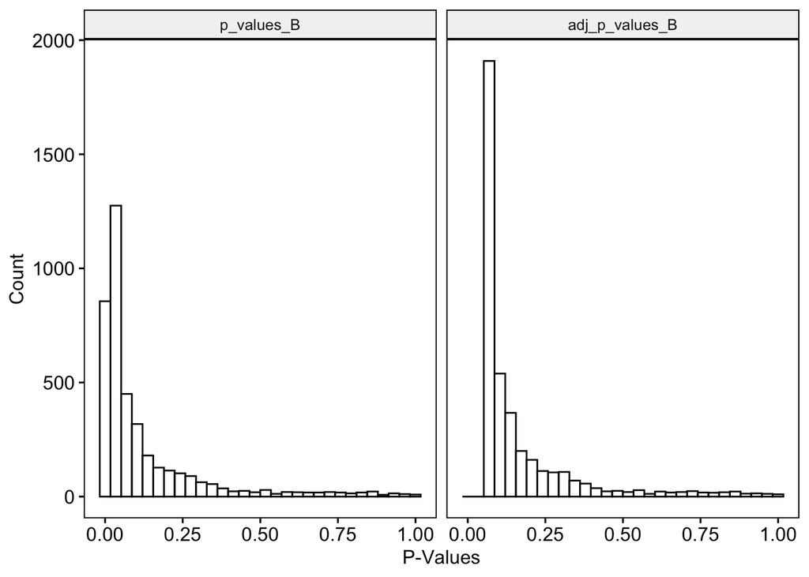

```r
#plot adjusted and unadjusted p-values
pvals_df <- data.frame(p_values_B, adj_p_values_B)
gghistogram(pvals_df,
       x = c("p_values_B", "adj_p_values_B"),
       y = "..count..",
       combine = TRUE,
       xlab = "P-Values",
       ylab = "Count",
       palette = "jco"
)
```

##### C) Finally, for each row in the spreadsheet perform an ANVOA comparing the three-parameter model from (A) and the two parameter model from (B). Plot out the histogram of all p-values. For how many genes is there a significant difference between these two models at a BH FDR-corrected threshold.

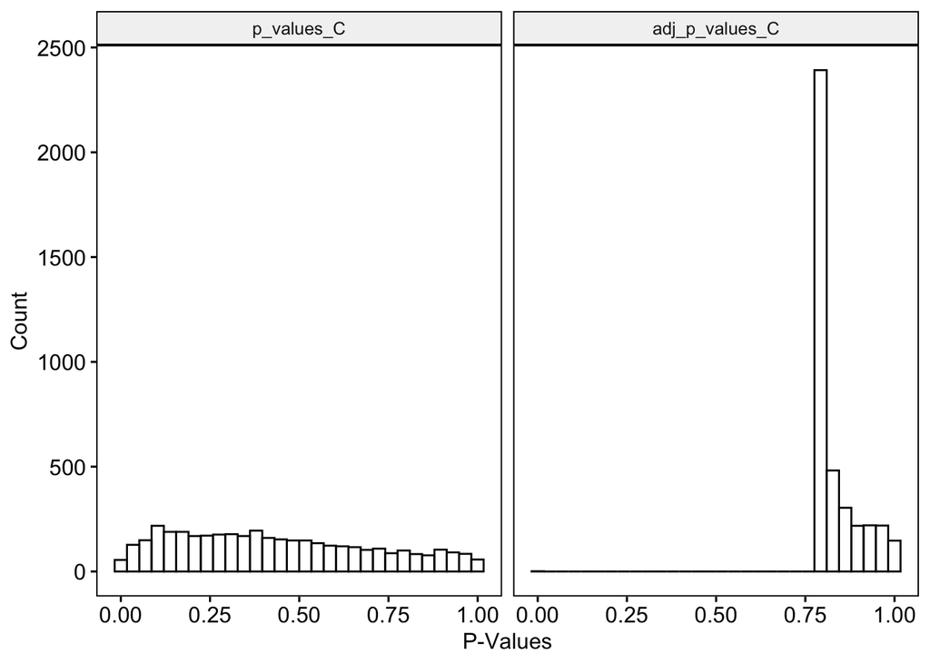

```r
f.stat <- vector(length=nrow(norm_data))
p_values_C <- vector(length=nrow(norm_data))
aic2p <- vector(length=nrow(norm_data))
aic3p <- vector(length=nrow(norm_data))


three_param <- c(rep("D2", 3), rep("W12", 3), rep("w20", 5))
two_param <- c(rep(2, 3), rep(86, 3), rep(128, 5))

#compare the two and three parameter models
for (gene in 1:nrow(norm_data)) {

  gene_exp <- as.numeric(unlist(data[gene,])) #make list into numeric vector for use in lm

  model_3p <- lm(gene_exp ~ three_param)
  anova_3p <- anova(model_3p)

  model_2p <- lm(gene_exp ~ two_param)
  anova_2p <- anova(model_2p)

  err_3p <- sum(residuals(model_3p)^2)
  df_3p <- anova_3p$Df[2]

  err_2p <- sum(residuals(model_2p)^2)
  df_2p <- anova_2p$Df[2]

  num <- (err_2p - err_3p) / (df_2p - df_3p )
  denom <- (err_3p / df_3p )

  f <- (num/denom)
  p_values_C[gene] <- pf(f, 1, 8, lower.tail = F)

   aic2p[gene] <- AIC(model_3p, model_2p)$AIC[2]
   aic3p[gene] <- AIC(model_3p, model_2p)$AIC[1]
}

adj_p_values_C <- p.adjust(p_values_C, method='BH')
sig_p_values <- adj_p_values_C[adj_p_values_C <= 0.05]

pvals_df <- data.frame(p_values_C, adj_p_values_C)
gghistogram(pvals_df,
       x = c("p_values_C", "adj_p_values_C"),
       y = "..count..",
       combine = TRUE,
       xlab = "P-Values",
       ylab = "Count",
       palette = "jco"
)
```

##### D) Make three graphs showing the relative abundance of the most significant gene under each of the three ANOVA models. For (A) and (C), the x-axis will the category (day 3, week 12 and week 18) and the y-axis will be the relative abundance. Be sure to properly label and title all graphs and axes. For (B) the x-axis will be time (in days) and the y-axis will be the relative abundance. For the graph of the top hit from (B), include the regression line for the plot from (B).

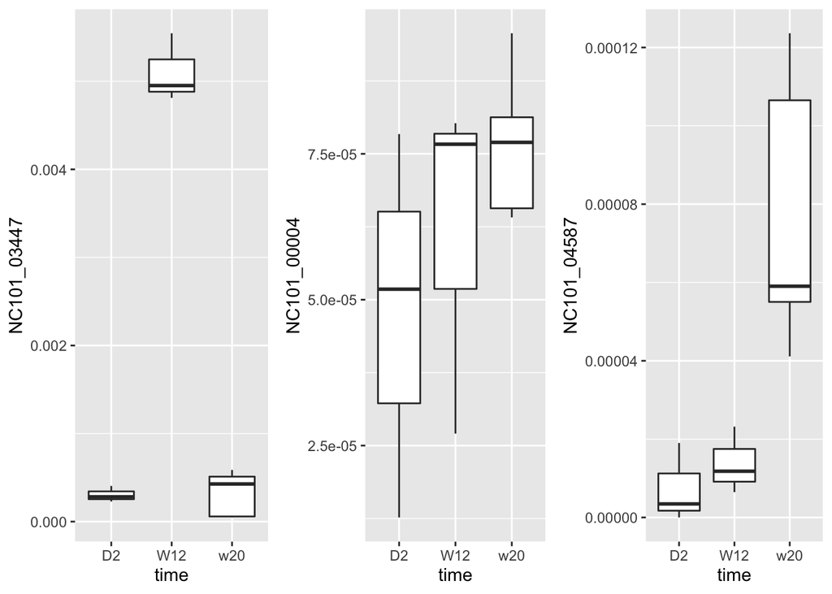

```r
low_a <- which.min(adj_p_values_A)
low_b <- which.min(adj_p_values_B)
low_c <- which.min(adj_p_values_C)

a <- as.data.frame(norm_data[low_a,])
b <- as.data.frame(norm_data[low_b,])
c <- as.data.frame(norm_data[low_c,])

a <- as.data.frame(t(a))
b <- as.data.frame(t(b))
c <- as.data.frame(t(c))

a <- tibble::rownames_to_column(a, "time")
b <- tibble::rownames_to_column(b, "time")
c <- tibble::rownames_to_column(c, "time")

a$time <- c(rep("D2", 3), rep("W12", 3), rep("w20", 5))
b$time <- c(rep("D2", 3), rep("W12", 3), rep("w20", 5))
c$time <- c(rep("D2", 3), rep("W12", 3), rep("w20", 5))

p1 <- ggplot(a, aes(x=time, y=NC101_03447)) + geom_boxplot()
p2 <- ggplot(b, aes(x=time, y=NC101_00004)) + geom_boxplot()
p3 <- ggplot(c, aes(x=time, y=NC101_04587)) + geom_boxplot()

ggarrange(p1, p2, p3, nrow=1)
```

##### E) Overall, do you think the three parameter model in (A) or the two-parameter model in (B) is more appropriate for these data? Justify your answer.

The average AIC from the two models is nearly identical with the 2p model slightly edging out the 3p model. However, I have a feeling that my 2p model is incorrect.

```r
mean(aic2p)
```

```
## [1] 128.6301
```

```r
mean(aic3p)
```

```
## [1] 128.9634
```